# pcwOrd: (partial) (constrained) (weighted) ordination

PME

3/2/2020

# Motivation

Many ordination packages exist for ecologists using R - `vegan` is excellent, for example. But none readily perform (to my knowledge) weighted, partial constrained ordinations.

The motivation for this is to analyze compositional ecological data - especially high throughput sequencing data - with methods that are robust, reproducible, and transparent. Compositional data contains only relative data (think relative abundance), and so requires a bit of extra care to analyze. The dominant approach is to perform a log-ratio transformation, then use principle components analysis - combined, this is called log-ratio analysis. For an enterance into this literature, see Greenacre and Aitchison (2002), Greenacre and Lewi (2009), and Quinn et al (2018).

`vegan` can perform constrained and partiald log-ratio analysis if the community matrix is log-transformed beforehand. However, it does not provide a straightforward way to weight columns and working with ordination objects is not intuitive. `easyCODA` allows weighted and constrained log-ratio analysis, but does not allow partialing of nuisance effects and does not provide hypothesis testing. `pcwOrd` allows partialed, constrained, and weighted ordinations, and also provides utility functions for investigating ordination objects, visualization, and hypothesis testing. The code is written to be self-documenting. Maybe you’ll agree.

This isn’t an R package yet, so load the functions with `source()`:

```r
# Libraries
libs = c('easyCODA',  # log-ratio analysis and CLR analysis
         'vegan',     # multivariate statistics
         'here')      # find files in your project directory

load_libs = function() {
  for(i in libs) {
    if (!require(i, character.only=TRUE)) {
      install.packages(i)
      library(i, character.only=TRUE)
    }
  }
}
load_libs()
# pcwOrd
source(here('Scripts', 'pcwOrd', 'pcwOrd.R'))

spider = readRDS(here('Scripts', 'pcwOrd', 'Spider.RDS'))
```

This vignette will demonstrate the features of pcwOrd: ordination, hypothesis-testing, and visualization. I’ll use the `spiders` dataset from `mvabund`. This dataset has two tables:

1. A `data.frame` of environmental variables, to which I’ll add a categorical version of `soil.dry`*.
2. A `matrix` of community data.

Certain pcwOrd functions use the rownames of the environmental and community data to cross-reference, so we want to ensure both tables have rownames. Usually these are something meaningful, like sample IDs.

*technically this should be ordinal, but we’ll treat it as categorical.

```r
# environmental data
envi = as.data.frame(spider$x)

# categorical soil wetness
cats = c('dry', 'damp', 'wet', 'soaking')
cc = ceiling(envi$soil.dry)
envi$soil.cat = factor(cats[cc],
                       levels=cats)

# community data
comm = as.matrix(spider$abund)

# rownames
nobs = nrow(comm)
row_names = c(letters[], LETTERS[])[1:nobs]
rownames(envi) = row_names
rownames(comm) = row_names

str(envi)
```

```
## 'data.frame':    28 obs. of  7 variables:
##  $ soil.dry     : num  2.33 3.05 2.56 2.67 3.02 ...
##  $ bare.sand    : num  0 0 0 0 0 ...
##  $ fallen.leaves: num  0 1.79 0 0 0 ...
##  $ moss         : num  3.04 1.1 2.4 2.4 0 ...
##  $ herb.layer   : num  4.45 4.56 4.61 4.62 4.62 ...
##  $ reflection   : num  3.91 1.61 3.69 3 2.3 ...
##  $ soil.cat     : Factor w/ 4 levels "dry","damp","wet",..: 3 4 3 3 4 4 4 3 3 3 ...
```

```r
comm[1:8, 1:8]
```

```
##   Alopacce Alopcune Alopfabr Arctlute Arctperi Auloalbi Pardlugu Pardmont
## a       25       10        0        0        0        4        0       60
## b        0        2        0        0        0       30        1        1
## c       15       20        2        2        0        9        1       29
## d        2        6        0        1        0       24        1        7
## e        1       20        0        2        0        9        1        2
## f        0        6        0        6        0        6        0       11
## g        2        7        0       12        0       16        1       30
## h        0       11        0        0        0        7       55        2
```

# Basic Functions

## Ordination

We’ll first perform a basic principle components analysis of the community with `pcwOrd()` and visualize the results with `plot_ord`:

```
## Rescaling standard scores by 10.12
```

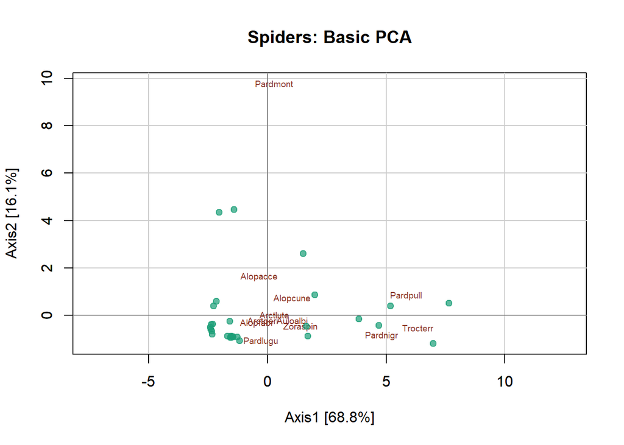

```r
pca = pcwOrd(comm)
plot_ord(pca,
         main='Spiders: Basic PCA')
```

The `pca` object is a list of class `pcwOrd` that contains a number of items. See the documentation for `pcwOrd`. Important ones are: `'Y_scaled'` - the community matrix after centering, scaling, and/or weighting but before further analysis; `'unconstrained'` - the singular value decomosition matrices (left `'u'` and right `'v'`) and values (`'d'`). All relevant information about this ordination can be calculated from these values.

### Eigenvalues

For example, if we want to calculate eigenvalues of this unconstrained ordination, we need to access the singular values (vector `d`) of the unconstrained solution:

```r
pca$unconstrained$d^2
```

```
##  [1] 251.7432705  58.7674666  25.3873166  11.7224346   5.6704074   4.1539497
##  [7]   2.7649418   2.3272743   1.6733360   0.8060037   0.6634983   0.1884040
```

### Axis Variances

We can view these same data by calling ord_variance, which summarizes the variance explained by each axis in the solution:

```r
ord_variance(pca)
```

```
## $type
## [1] "variance"
##
## $summary
##              total partialed constrained unconstrained
## value     365.8683         0           0      365.8683
## pct_total 100.0000         0           0      100.0000
##
## $total
##              Total
## value     365.8683
## pct_group 100.0000
## pct_total 100.0000
##
## $partialed
##
## value
## pct_group
## pct_total
##
## $constrained
##
## value
## pct_group
## pct_total
##
## $unconstrained
##              uAxis1   uAxis2    uAxis3    uAxis4   uAxis5   uAxis6    uAxis7
## value     251.74327 58.76747 25.387317 11.722435 5.670407 4.153950 2.7649418
## pct_group  68.80707 16.06246  6.938922  3.204004 1.549849 1.135367 0.7557205
## pct_total  68.80707 16.06246  6.938922  3.204004 1.549849 1.135367 0.7557205
##              uAxis8    uAxis9   uAxis10   uAxis11    uAxis12
## value     2.3272743 1.6733360 0.8060037 0.6634983 0.18840395
## pct_group 0.6360962 0.4573602 0.2202989 0.1813489 0.05149502
## pct_total 0.6360962 0.4573602 0.2202989 0.1813489 0.05149502
```

### Scree plots

We can also visualize variances across axes in a scree plot with `ord_scree()`:

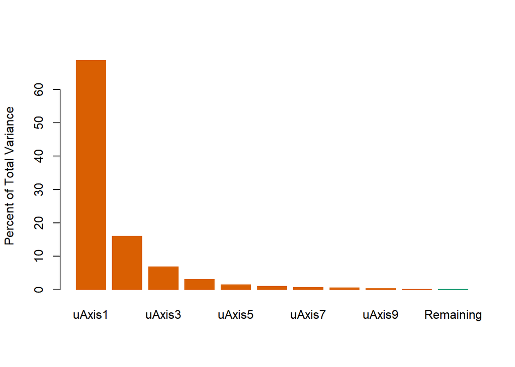

```r
ord_scree(pca)
```

### Calculate scores

If you want to make your own biplots, you can calculate row, column, centeroid, and biplot scores by calling `ord_scores`. Scores can be principle, standard, or contribution - with the latter being raw singular values (either `'u'` or `'v'`). To make plotting easy, we can also add grouping information from the `envi` table:

```r
grp = envi[, 'soil.cat', drop=FALSE] # preserve rownames
rowscores = ord_scores(pca,
                       choice='row',
                       scaling='principle',
                       axes=c(1:3),
                       add_grouping=grp)
head(rowscores)
```

```
##      Axis1      Axis2      Axis3 soil.cat
## a 1.509623  2.6053593 -0.6811249      wet
## b 1.706576 -0.8793122 -1.0806346  soaking
## c 2.004352  0.8598015 -0.6754797      wet
## d 4.702137 -0.4294234 -1.6207403      wet
## e 6.987565 -1.1952552  3.6085514  soaking
## f 1.641038 -0.4773010 -0.3333297  soaking
```

When plotting both standard and principle scores, often you’ll need to rescale one of them for visualization:

```r
colscores = ord_scores(pca,
                       choice='column',
                       scaling='standard',
                       axes=c(1:3))
scaled_colscores = scale_scores(colscores,
                                rowscores) # can also specify manual scaling factor
```

```
## Rescaling standard scores by 8.271
```

```r
lapply(list(original = colscores,
            rescaled = scaled_colscores),
       head)
```

```
## $original
##                Axis1       Axis2       Axis3
## Alopacce -0.03365963  0.16120685  0.06324170
## Alopcune  0.10223352  0.07024215  0.04972208
## Alopfabr -0.04435444 -0.03233246  0.08709767
## Arctlute  0.03001178  0.00254796  0.01295151
## Arctperi -0.01985399 -0.02338508  0.03683295
## Auloalbi  0.10368699 -0.01977533 -0.12316564
##
## $rescaled
##               Axis1       Axis2      Axis3
## Alopacce -0.2784154  1.33342131  0.5231032
## Alopcune  0.8456238  0.58100745  0.4112758
## Alopfabr -0.3668775 -0.26743774  0.7204277
## Arctlute  0.2482422  0.02107543  0.1071284
## Arctperi -0.1642221 -0.19342952  0.3046635
## Auloalbi  0.8576462 -0.16357151 -1.0187637
```

### Identify top features

Finally, it’s useful to identify the top features. The default `scaling='contribution'` gives top contribution scores - i.e. the features that contribute most to the axes chosen. Here, we identify the spider taxa that have the five highest mean contributions across the first two axes:

```r
top_scores(pca, n=5, choice='column', scaling='contribution', axes=c(1:2))
```

```
##          mean_contribution
## Pardmont         0.9681618
## Trocterr         0.6288081
## Pardpull         0.5841149
## Pardnigr         0.4835553
## Alopacce         0.1646834
## attr(,"axes")
## [1] 1 2
```

# More ordinations

## Log-ratio analysis

To perform log-ratio analysis:

1. Remove zeros from your data. For simplicity, I’ll replace zeros with a pseudocount of 0.5. Note that I am *not* adding the pseudocount as `x + 0.5`, as this will distort the ratios between observations.
2. Close the community matrix, so that all abundances are relative abundances and `rowSums(x) = 1`.
3. Perform the log-ratio transformation of your choice. The centered log-ratio (CLR), where values are centered on the geometric mean, is a common choice.
4. Run principle components analysis on the log-ratio transformed matrix

```
## Rescaling standard scores by 0.7505
```

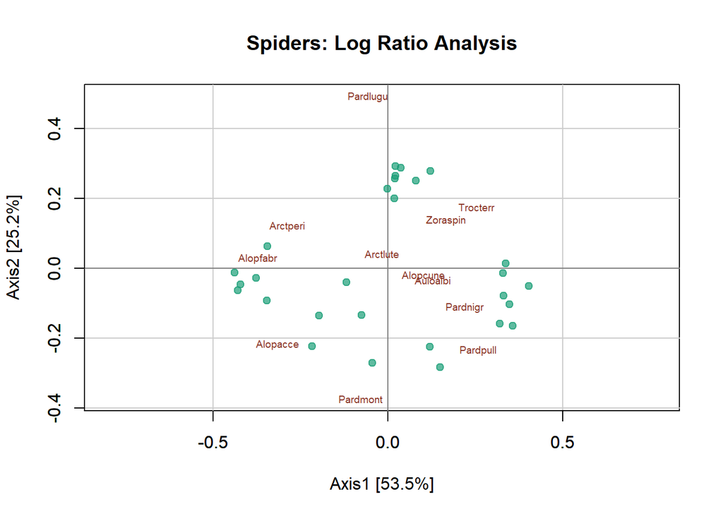

```r
# Pseudocounts
cc = comm
cc[cc==0] = 0.5 # replace zeros without adding to all values!

# Close the community
closed_comm = sweep(cc, 1, rowSums(comm), '/') # close to relative abundance

# perform centered log-ratio
geo_mean = apply(closed_comm, 1,
                 function(x) {
                   exp(sum(log(x))/length(x))
                 })
lr_comm =  sweep(closed_comm, 1, geo_mean, '/')
lr_comm = log(lr_comm, 2)

lra = pcwOrd(lr_comm)
plot_ord(lra,
         main='Spiders: Log Ratio Analysis')
```

## Weighted ordinations

Here is a weighted LRA:

```
## Rescaling standard scores by 0.1744
```

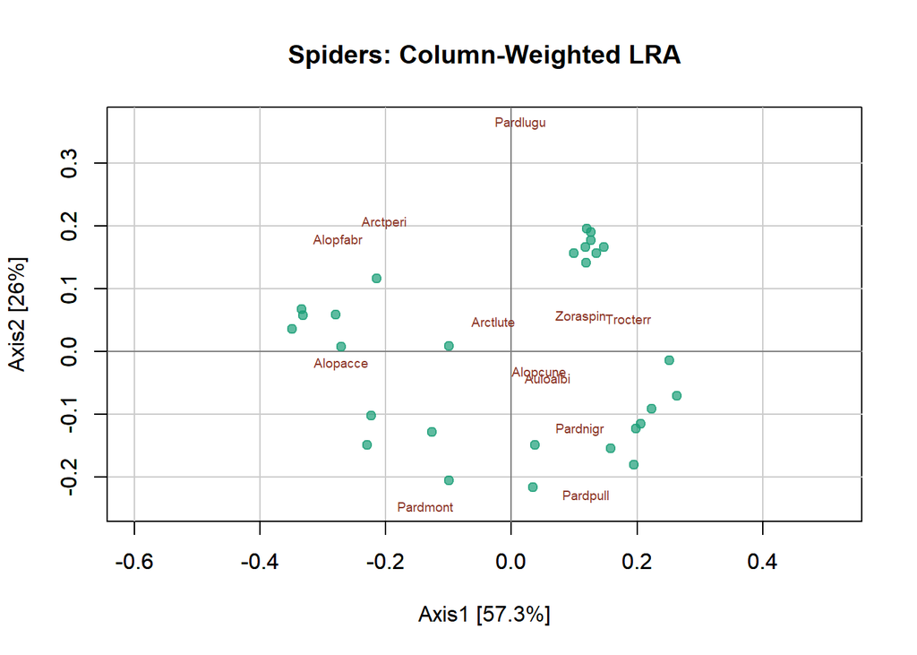

```r
wlr_comm = CLR(closed_comm) # CLR based on column-weighted geometric mean, plus column weights

w_lra = pcwOrd(wlr_comm)
plot_ord(w_lra,
         main='Spiders: Column-Weighted LRA')
```

In this situation, the results of weighted and unweighted ordinations are approximately the same. See Greenacre and Lewi (2009) for a discussion of when weighted log-ratio analysis might be advantageous over a non-weighted log ratio analysis.

## Constrained ordination

We might be interested in how these spiders associate with environmental variables. For example, we might be interested in whether moss and reflection structures spider communities. A constrained ordination like redundancy analysis will do this: pcwOrd will regress the community matrix against moss and reflectivity, and then ordinate the fitted values.

```
## Rescaling standard scores by 8.774
```

```
## Rescaling standard scores by 9.116
```

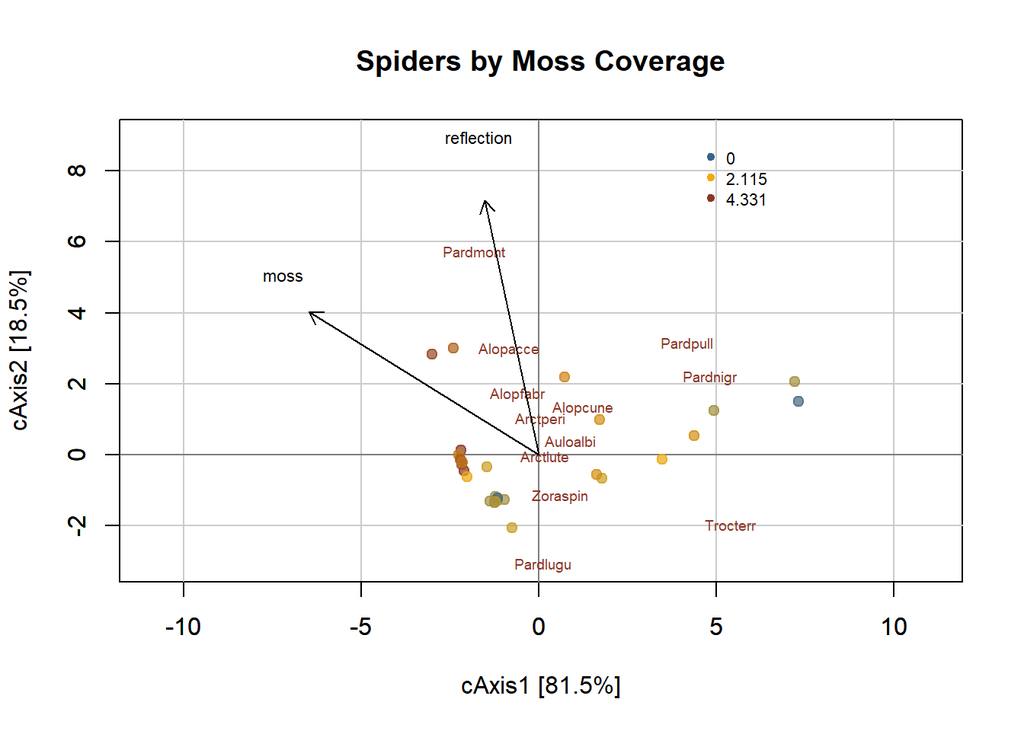

```r
X = envi[, c('moss', 'reflection')] # preserve rownames
rda = pcwOrd(comm, X=X)

plot_ord(rda,
         main='Spiders by Moss Coverage',
         color_legend_position=c(0.8, 0))
```

In this plot, colors show moss coverage, the first column in X.

### Significance testing

```r
pp = permute_ord(rda)
pp
```

```
##   permute_on total_variance variance_after_partialing   fitted residuals num_df
## 1    partial       365.8683                  365.8683 98.72652  267.1418      2
##   denom_df   F_stat p_val F_perm
## 1       25 4.619575 0.006    999
```

`permute_ord()` has a number of permutation models that parallel the options in `vegan::permutest()` - and `permute_ord()` will return the same results as `vegan::permutest()` with the same randomization seed. We see a p-value of 0.006 after 999 permutations.

## Partial ordination

Say we want to look at how moass affects spider communities independently of moisture class. We can partial this out as Z:

```
## Rescaling standard scores by 0.03821
```

```
## Rescaling standard scores by 0.05596
```

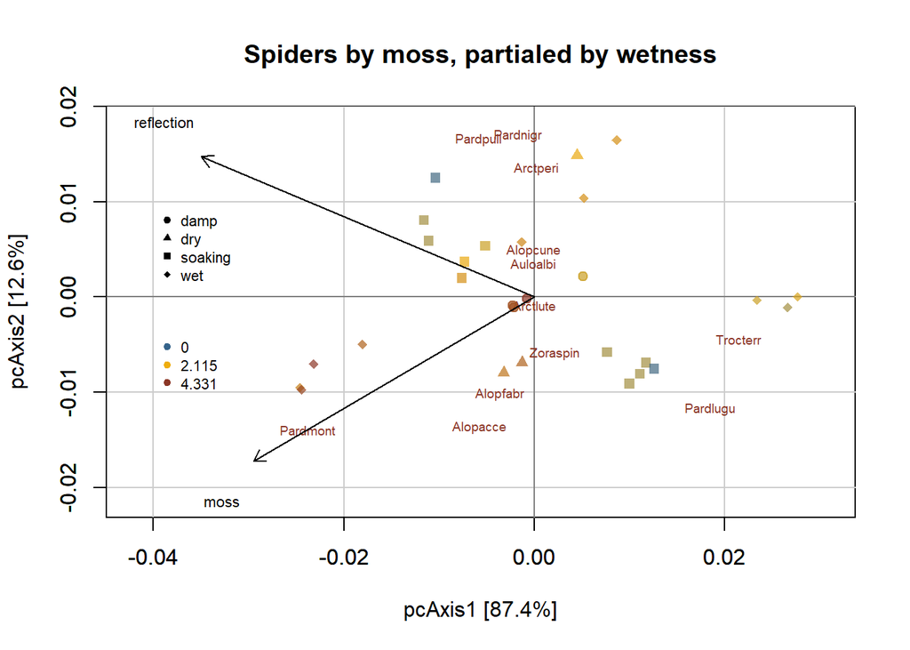

```r
Z = envi[, 'soil.cat', drop=FALSE] # preserve rownames
X = envi[, c('moss', 'reflection'), drop=FALSE]

pcrda = pcwOrd(closed_comm, X, Z)

plot_ord(pcrda,
         main='Spiders by moss, partialed by wetness',
         shape_legend_position=c(-0.04, 0.01))
```

Each of the wetness categories is centered at zero, as expected due to partialing. Moss increases to the bottom left (darker red, and arrows). This model is highly significant:

```r
permute_ord(pcrda)
```

```
##   permute_on total_variance variance_after_partialing      fitted   residuals
## 1    partial     0.01927485                0.01070139 0.004584283 0.006117103
##   num_df denom_df   F_stat p_val F_perm
## 1      2       22 8.243627 0.001    999
```

## Partialed, constrained, weighted ordination

The reason for this package is to perform partial, constrained, weighted ordinations. Here is a weighted log-ratio analysis of the spider community, constrained by moss and reflection, with moisture category partialed out:

```
## Rescaling standard scores by 0.1324
```

```
## Rescaling standard scores by 0.6076
```

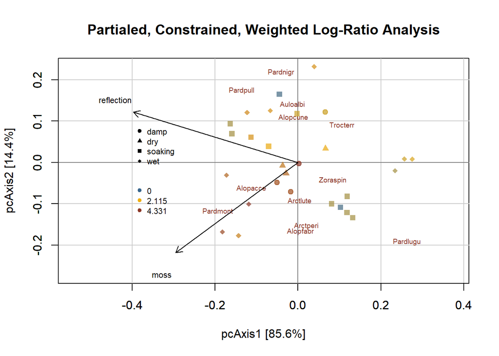

```r
Y = CLR(closed_comm)

pcw_ord = pcwOrd(Y, X, Z)

plot_ord(pcw_ord,
         main='Partialed, Constrained, Weighted Log-Ratio Analysis',
         shape_legend_position=c(-0.4, 0.1))
```

# Comparison to `vegan` and `easyCODA`

Returning to eigenvalues: these eigenvalues are exactly the same as calculated by easyCODA’s PCA, and solutions are the same:

```r
easy_pca = PCA(comm, weight=FALSE)
rbind(pcwOrd = pca$unconstrained$d^2,
      easyCODA = easy_pca$sv^2
)
```

```
##              [,1]     [,2]     [,3]     [,4]     [,5]    [,6]     [,7]     [,8]
## pcwOrd   251.7433 58.76747 25.38732 11.72243 5.670407 4.15395 2.764942 2.327274
## easyCODA 251.7433 58.76747 25.38732 11.72243 5.670407 4.15395 2.764942 2.327274
##              [,9]     [,10]     [,11]    [,12]
## pcwOrd   1.673336 0.8060037 0.6634983 0.188404
## easyCODA 1.673336 0.8060037 0.6634983 0.188404
```

Eigenvalues are not identical to `vegan` eigenvalues, because `pcwOrd` (and `easyCODA`) weights the initial community matrix rows by `1/sqrt(nrow)`, while `vegan` weights rows by `1/sqrt(nrow-1)`. You can access `vegan`-style weighting, which will agree with vegan results:

```r
veganlike_pca = pcwOrd(comm, as_vegan=TRUE)
vegan_pca = rda(comm)

rbind(pcwOrd = veganlike_pca$unconstrained$d^2,
      vegan = vegan_pca$CA$eig)
```

```
##             PC1      PC2      PC3      PC4      PC5     PC6      PC7      PC8
## pcwOrd 3132.805 731.3285 315.9311 145.8792 70.56507 51.6936 34.40816 28.96164
## vegan  3132.805 731.3285 315.9311 145.8792 70.56507 51.6936 34.40816 28.96164
##             PC9     PC10     PC11     PC12
## pcwOrd 20.82374 10.03027 8.256867 2.344583
## vegan  20.82374 10.03027 8.256867 2.344583
```

These weightings don’t change relative variance or relative distances, only absolute variances and distances. Generally, we’re concerned with relative variances and distances, so the choice of (equal) weighting doesn’t matter.

```r
list(
  coda_weightings = ord_variance(pca)$unconstrained,
  vegan_weightings = ord_variance(veganlike_pca)$unconstrained
)
```

```
## $coda_weightings
##              uAxis1   uAxis2    uAxis3    uAxis4   uAxis5   uAxis6    uAxis7
## value     251.74327 58.76747 25.387317 11.722435 5.670407 4.153950 2.7649418
## pct_group  68.80707 16.06246  6.938922  3.204004 1.549849 1.135367 0.7557205
## pct_total  68.80707 16.06246  6.938922  3.204004 1.549849 1.135367 0.7557205
##              uAxis8    uAxis9   uAxis10   uAxis11    uAxis12
## value     2.3272743 1.6733360 0.8060037 0.6634983 0.18840395
## pct_group 0.6360962 0.4573602 0.2202989 0.1813489 0.05149502
## pct_total 0.6360962 0.4573602 0.2202989 0.1813489 0.05149502
##
## $vegan_weightings
##               uAxis1    uAxis2     uAxis3     uAxis4    uAxis5    uAxis6
## value     3132.80514 731.32847 315.931051 145.879186 70.565070 51.693597
## pct_group   68.80707  16.06246   6.938922   3.204004  1.549849  1.135367
## pct_total   68.80707  16.06246   6.938922   3.204004  1.549849  1.135367
##               uAxis7     uAxis8     uAxis9    uAxis10   uAxis11    uAxis12
## value     34.4081650 28.9616352 20.8237366 10.0302687 8.2568673 2.34458251
## pct_group  0.7557205  0.6360962  0.4573602  0.2202989 0.1813489 0.05149502
## pct_total  0.7557205  0.6360962  0.4573602  0.2202989 0.1813489 0.05149502
```

`vegan::permutest()` gives the same as `pcwOrd::permute_ord()`, if you set the same seed.

```r
vegan_rda = rda(comm, X)
veganlike_rda = pcwOrd(comm, X, as_vegan=TRUE)

set.seed(445)
vegan_permutes = permutest(vegan_rda,
                           permutations=999)
set.seed(445)
pcw_permutes = permute_ord(veganlike_rda)
keep = c('fitted', 'residuals', 'num_df', 'denom_df', 'F_stat', 'p_val')

list(vegan = vegan_permutes,
     pcwOrd = pcw_permutes[keep])
```

```
## $vegan
##
## Permutation test for rda under reduced model
##
## Permutation: free
## Number of permutations: 999
##
## Model: rda(X = comm, Y = X)
## Permutation test for all constrained eigenvalues
##          Df Inertia      F Pr(>F)
## Model     2  1228.6 4.6196  0.004 **
## Residual 25  3324.4
## ---
## Signif. codes:  0 '***' 0.001 '**' 0.01 '*' 0.05 '.' 0.1 ' ' 1
##
## $pcwOrd
##     fitted residuals num_df denom_df   F_stat p_val
## 1 1228.597  3324.431      2       25 4.619575 0.004
```

# Additional plotting options

## Added categories

Add groupings to any ordination. They can be continuous.

```
## Rescaling standard scores by 10.12
```

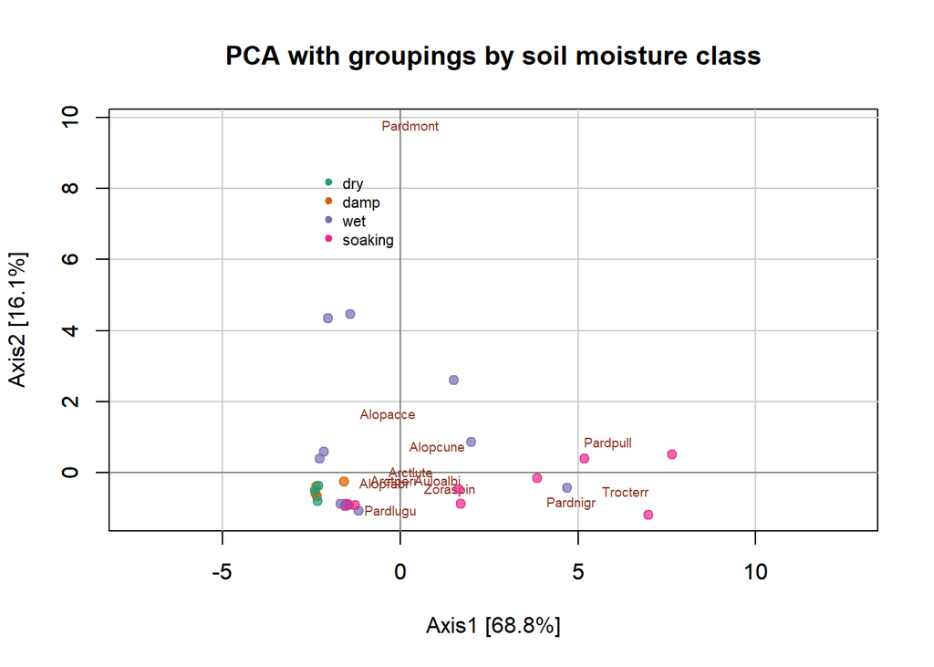

```r
row_group = envi[, 'soil.cat', drop=FALSE]
plot_ord(pca,
         row_group=row_group,
         main='PCA with groupings by soil moisture class')
```

## Different axes

Plot different axes

```
## Rescaling standard scores by 3.592
```

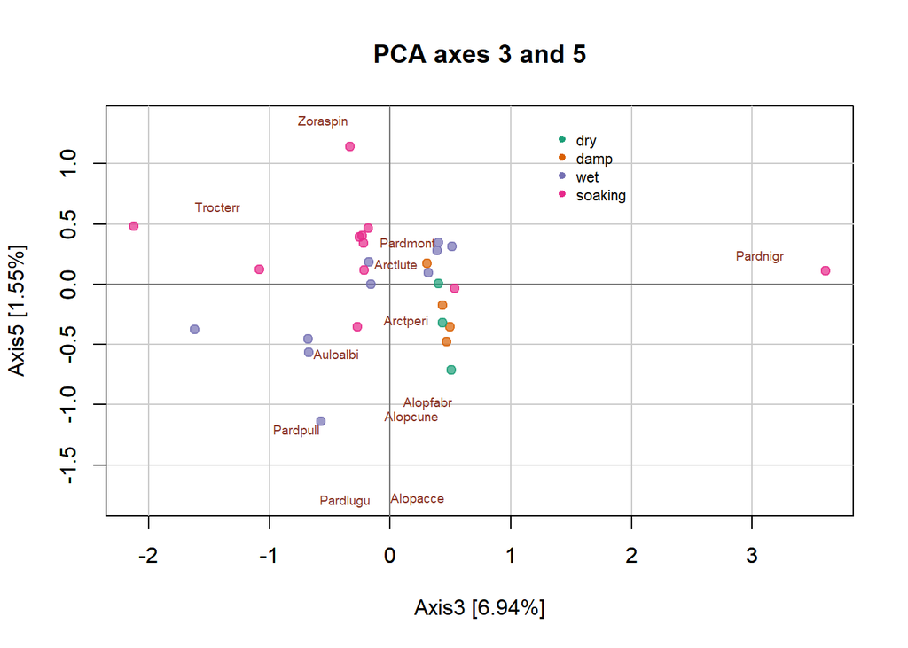

```r
plot_ord(pca,
         row_group=row_group,
         axes=c(3,5),
         main='PCA axes 3 and 5',
         color_legend_position=c(0.6, 0))
```

## Limit column labels

Reduce clutter by only labeling the top columns (by plotted score)

```
## Rescaling standard scores by 10.12
```

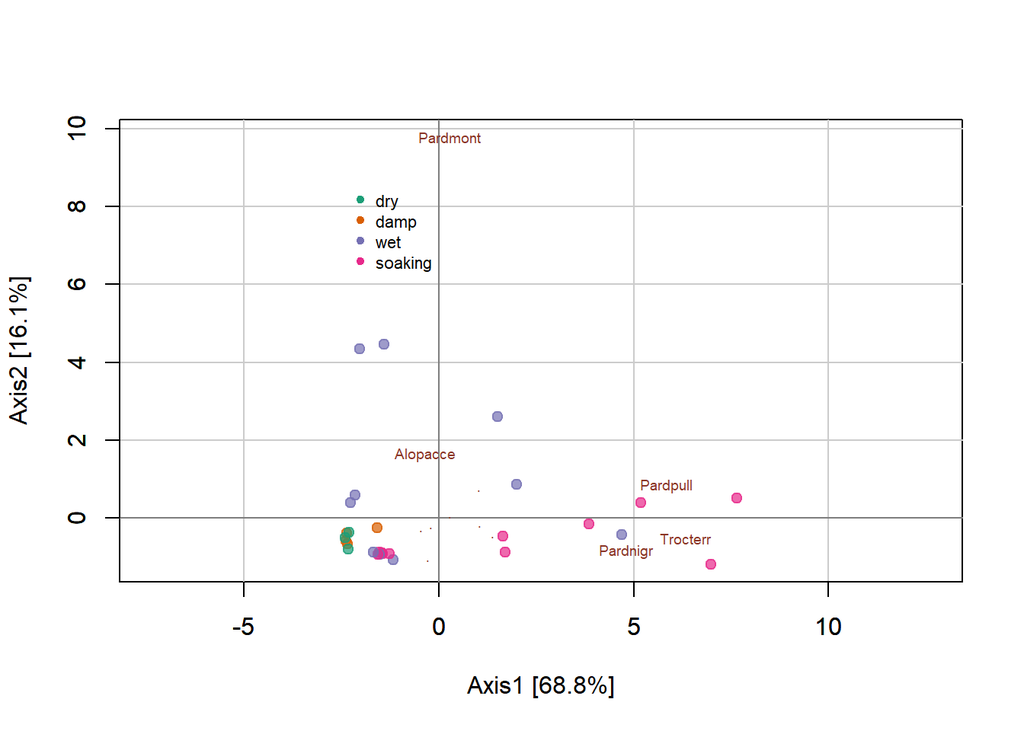

```r
plot_ord(pca,
         row_group=row_group,
         max_labels=5)
```

## colors and shapes

Change the colors of text, groupings, arrows, and change shapes.

```
## Rescaling standard scores by 10.12
```

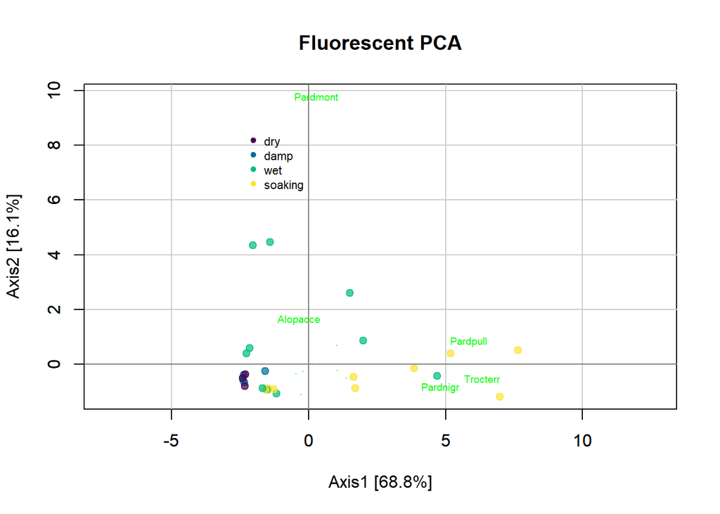

```r
new_colors = hcl.colors(4, palette='Viridis')

plot_ord(pca,
         row_group=row_group,
         max_labels=5,
         discrete_scale=new_colors,
         col_text='green',
         main='Fluorescent PCA')
```

If you constrain an ordination with categories, the plot function will automatically recognize these and plot them as named centeroids:

```
## Rescaling standard scores by 0.1624
```

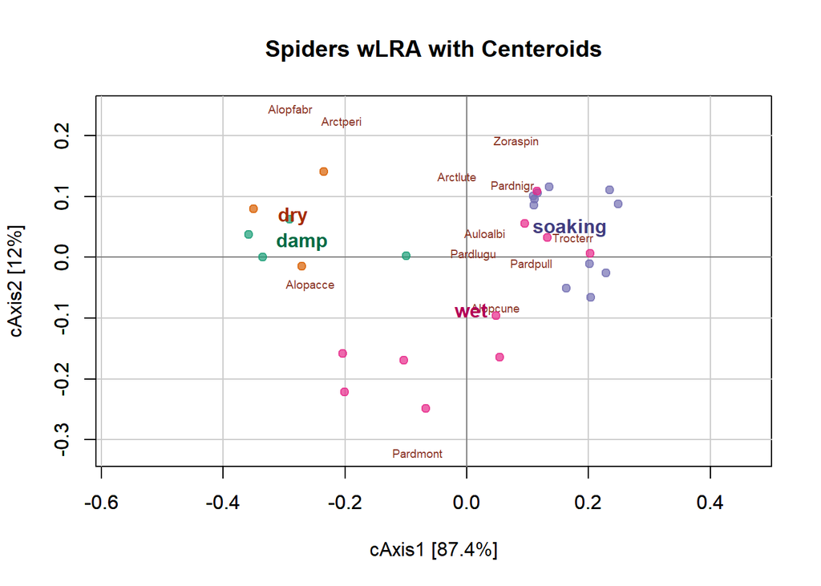

```r
X = envi[, 'soil.cat', drop=FALSE]
Y = CLR(closed_comm)

cat_cwLRA = pcwOrd(Y, X)

plot_ord(cat_cwLRA,
         main='Spiders wLRA with Centeroids')
```

## Screeplots as grobs

Screeplots can be produced as grobs (via ggplot2) for downstream manipulation, saving as R objects, and arranging with `gridExtra`. If you want to do this with ordinations, you’re on your own!

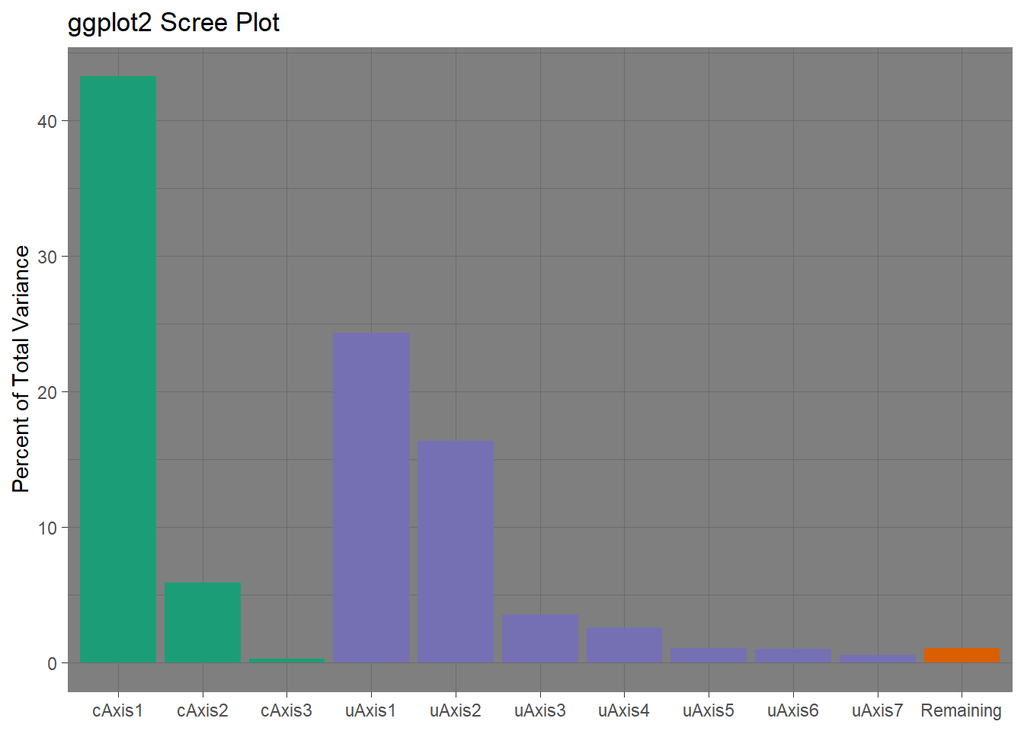

```r
ord_scree(cat_cwLRA, main='ggplot2 Scree Plot', as_grob=TRUE) +
  theme_dark()
```